# CAPSTONE PROJECT1: Real Estate Case Study

```python
print(list(density_eda_df.nsmallest(150, 'median_age').state.unique()))
print(len(list(density_eda_df.nsmallest(150, 'median_age').state.unique())))
```

```
['New York', 'Ohio', 'Georgia', 'New Jersey', 'Texas', 'Colorado', 'Virginia', 'California', 'Mississippi', 'Oregon', 'Arizona', 'Utah', 'Pennsylvania', 'Michigan', 'Arkansas', 'Maine', 'Florida', 'North Carolina', 'Minnesota', 'Iowa', 'Connecticut', 'Maryland', 'Wisconsin', 'Louisiana', 'Alabama', …
34
```

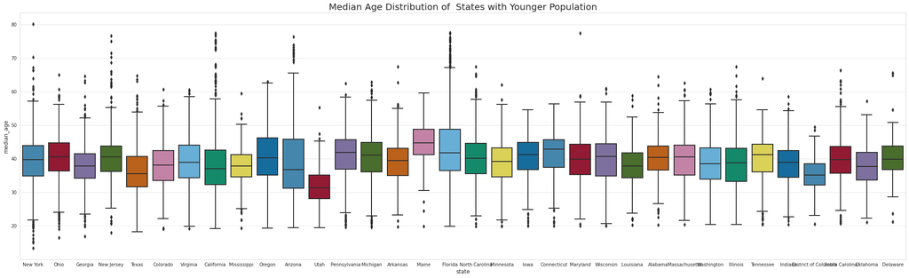

```python
sns.set_style("whitegrid")
plt.figure(figsize = (35, 10))
ax = sns.boxplot(x = 'state', y = 'median_age', data=density_eda_df.nsmallest(26585, 'median_age'), palette=color_pal,
            order = ['New York', 'Ohio', 'Georgia', 'New Jersey', 'Texas', 'Colorado', 'Virginia', 'California', 'Mississippi', 'Oregon', 'Arizona', 'Utah', 'Pennsylvania', 'Michigan', 'Arkansas', 'Maine', 'Florida', 'North Carolina',
                     'Minnesota', 'Iowa', 'Connecticut', 'Maryland', 'Wisconsin', 'Louisiana', 'Alabama', 'Massachusetts', 'Washington', 'Illinois', 'Tennessee', 'Indiana', 'District of Columbia', 'South Carolina', 'Oklahoma', 'Delaware']
           ).set_title('Median Age Distribution of  States with Younger Population', fontsize = 20)
#ax.set(ylim=(0, 100))
plt.show()
```

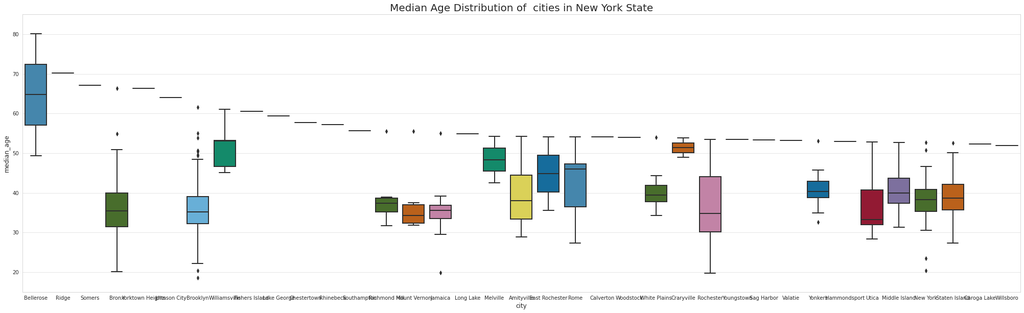

```python
sns.set_style("whitegrid")
plt.figure(figsize = (35, 10))
ax = sns.boxplot(x = 'city', y = 'median_age', data=density_eda_df[density_eda_df['state'] == 'New York'].nlargest(26585, 'median_age'), palette=color_pal,
            order =['Bellerose', 'Ridge', 'Somers', 'Bronx', 'Yorktown Heights', 'Johnson City', 'Brooklyn', 'Williamsville', 'Fishers Island', 'Lake George', 'Chestertown', 'Rhinebeck',
                    'Southampton', 'Richmond Hill', 'Mount Vernon', 'Jamaica', 'Long Lake', 'Melville', 'Amityville', 'East Rochester', 'Rome', 'Calverton', 'Woodstock', 'White Plains', 'Craryville',
                    'Rochester', 'Youngstown', 'Sag Harbor', 'Valatie', 'Yonkers', 'Hammondsport', 'Utica', 'Middle Island', 'New York', 'Staten Island', 'Caroga Lake', 'Willsboro']
)
ax.set_title('Median Age Distribution of  cities in New York State', fontsize = 20)
ax.set(ylim=(15, 85))
plt.show()
```

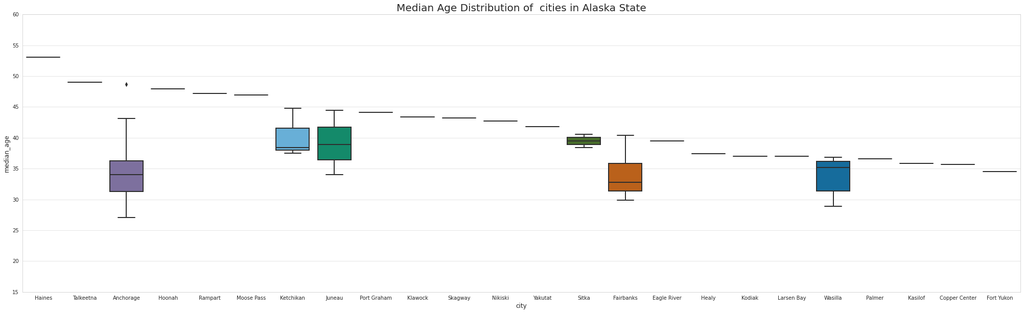

```python
sns.set_style("whitegrid")
plt.figure(figsize = (35, 10))
ax = sns.boxplot(x = 'city', y = 'median_age', data=density_eda_df[density_eda_df['state'] == 'Alaska'].nlargest(26585, 'median_age'), palette=color_pal,
            order =['Haines', 'Talkeetna', 'Anchorage', 'Hoonah', 'Rampart', 'Moose Pass', 'Ketchikan', 'Juneau', 'Port Graham', 'Klawock', 'Skagway', 'Nikiski', 'Yakutat', 'Sitka', 'Fairbanks',
                    'Eagle River', 'Healy', 'Kodiak', 'Larsen Bay', 'Wasilla', 'Palmer', 'Kasilof', 'Copper Center', 'Fort Yukon']
)
ax.set_title('Median Age Distribution of  cities in Alaska State', fontsize = 20)
ax.set(ylim=(15, 60))
plt.show()
```

```python
list(density_eda_df[density_eda_df['state'] == 'New York'].nlargest(600, 'pop_density').place.unique())
print(len(list(density_eda_df[density_eda_df['state'] == 'New York'].nlargest(600, 'pop_density').place.unique())))
```

```
19
```

```python
print(list(density_eda_df[density_eda_df['state'] == 'Alaska'].nlargest(42, 'median_age').city.unique()))
print(len(list(density_eda_df[density_eda_df['state'] == 'Alaska'].nlargest(42, 'median_age').city.unique())))
```

```
['Haines', 'Talkeetna', 'Anchorage', 'Hoonah', 'Rampart', 'Moose Pass', 'Ketchikan', 'Juneau', 'Port Graham', 'Klawock', 'Skagway', 'Nikiski', 'Yakutat', 'Sitka', 'Fairbanks', 'Eagle River', 'Healy', 'Kodiak', 'Larsen Bay', 'Wasilla', 'Palmer', 'Kasilof', 'Copper Center', 'Fort Yukon']
24
```

```python
train_df.head()
```

|  | UID | SUMLEVEL | COUNTYID | STATEID | state | state_ab | city | place | type | zip_code | area_code | lat | lng | ALand | AWater | pop | male_pop | female_pop | rent_mean | rent_median | rent_stdev | rent_sample_weight | rent_samples | rent_gt_10 | rent_gt_15 | rent_gt_20 | rent_gt_25 | rent_gt_30 | rent_gt_35 | … |
| --- | --- | --- | --- | --- | --- | --- | --- | --- | --- | --- | --- | --- | --- | --- | --- | --- | --- | --- | --- | --- | --- | --- | --- | --- | --- | --- | --- | --- | --- | --- |
| 0 | 267822 | 140 | 53 | 36 | New York | NY | Hamilton | Hamilton | City | 13346 | 315 | 42.840812 | -75.501524 | 202183361.0 | 1699120 | 5230 | 2612 | 2618 | 769.38638 | 784.0 | 232.63967 | 272.34441 | 362.0 | 0.86761 | 0.79155 | 0.59155 | 0.45634 | 0.42817 | 0.18592 | … |
| 1 | 246444 | 140 | 141 | 18 | Indiana | IN | South Bend | Roseland | City | 46616 | 574 | 41.701441 | -86.266614 | 1560828.0 | 100363 | 2633 | 1349 | 1284 | 804.87924 | 848.0 | 253.46747 | 312.58622 | 513.0 | 0.97410 | 0.93227 | 0.69920 | 0.69920 | 0.55179 | 0.41235 | … |
| 2 | 245683 | 140 | 63 | 18 | Indiana | IN | Danville | Danville | City | 46122 | 317 | 39.792202 | -86.515246 | 69561595.0 | 284193 | 6881 | 3643 | 3238 | 742.77365 | 703.0 | 323.39011 | 291.85520 | 378.0 | 0.95238 | 0.88624 | 0.79630 | 0.66667 | 0.39153 | 0.39153 | … |
| 3 | 279653 | 140 | 127 | 72 | Puerto Rico | PR | San Juan | Guaynabo | Urban | 927 | 787 | 18.396103 | -66.104169 | 1105793.0 | 0 | 2700 | 1141 | 1559 | 803.42018 | 782.0 | 297.39258 | 259.30316 | 368.0 | 0.94693 | 0.87151 | 0.69832 | 0.61732 | 0.51397 | 0.46927 | … |
| 4 | 247218 | 140 | 161 | 20 | Kansas | KS | Manhattan | Manhattan City | City | 66502 | 785 | 39.195573 | -96.569366 | 2554403.0 | 0 | 5637 | 2586 | 3051 | 938.56493 | 881.0 | 392.44096 | 1005.42886 | 1704.0 | 0.99286 | 0.98247 | 0.91688 | 0.84740 | 0.78247 | 0.60974 | … |

# 2. Create bins for population into a new variable by selecting appropriate class interval so that the number of categories don’t exceed 5 for the ease of analysis. a) Analyze the married, separated, and divorced population for these population brackets b) Visualize using appropriate chart type.

```python
age_df = train_df[['state', 'city', 'place', 'pop', 'male_pop', 'female_pop', 'male_age_median', 'female_age_median', 'married', 'separated', 'divorced']]
```

```python
train_df.male_age_median.unique()
```

[output not shown]

[output cut: 58 more lines]

[output not shown]

The IntelliSense Age Group defaults are:

Youth (<18)

Young Adult (18 to 35)

Adult (36 to 55)

Senior (56 and up)

```python
bins = [0, 12,18, 35, 55, 100]
labels = ['kids', 'Youth', 'Young Adult', 'Adult', 'Senior']
#df['binned'] = pd.cut(df['percentage'], bins, labels = labels)
```

```python
age_df['male_population_bracket'] = pd.cut(age_df['male_age_median'], bins, labels = labels)
```

```python
age_df['female_population_bracket'] = pd.cut(age_df['female_age_median'], bins, labels = labels)
```

```python
age_df.head()
```

|  | state | city | place | pop | male_pop | female_pop | male_age_median | female_age_median | married | separated | divorced | male_population_bracket | female_population_bracket |
| --- | --- | --- | --- | --- | --- | --- | --- | --- | --- | --- | --- | --- | --- |
| 0 | New York | Hamilton | Hamilton | 5230 | 2612 | 2618 | 44.00000 | 45.33333 | 0.57851 | 0.01240 | 0.08770 | Adult | Adult |
| 1 | Indiana | South Bend | Roseland | 2633 | 1349 | 1284 | 32.00000 | 37.58333 | 0.34886 | 0.01426 | 0.09030 | Young Adult | Adult |
| 2 | Indiana | Danville | Danville | 6881 | 3643 | 3238 | 40.83333 | 42.83333 | 0.64745 | 0.01607 | 0.10657 | Adult | Adult |
| 3 | Puerto Rico | San Juan | Guaynabo | 2700 | 1141 | 1559 | 48.91667 | 50.58333 | 0.47257 | 0.02021 | 0.10106 | Adult | Adult |
| 4 | Kansas | Manhattan | Manhattan City | 5637 | 2586 | 3051 | 22.41667 | 21.58333 | 0.12356 | 0.00000 | 0.03109 | Young Adult | Young Adult |

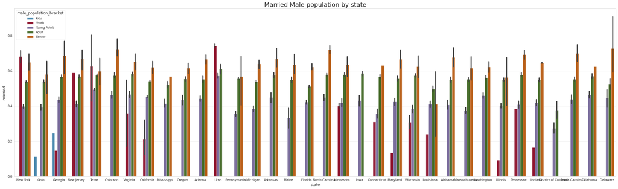

```python
sns.set_style("whitegrid")

plt.figure(figsize = (35, 10))

ax = sns.barplot(x = 'state', y = 'married', hue = 'male_population_bracket', data = age_df, palette=color_pal,
           order = ['New York', 'Ohio', 'Georgia', 'New Jersey', 'Texas', 'Colorado', 'Virginia', 'California', 'Mississippi', 'Oregon', 'Arizona', 'Utah', 'Pennsylvania', 'Michigan', 'Arkansas', 'Maine', 'Florida', 'North Carolina',
                     'Minnesota', 'Iowa', 'Connecticut', 'Maryland', 'Wisconsin', 'Louisiana', 'Alabama', 'Massachusetts', 'Washington', 'Illinois', 'Tennessee', 'Indiana', 'District of Columbia', 'South Carolina', 'Oklahoma', 'Delaware'])

ax.set_title('Married Male population by state', fontsize = 20)

plt.show()
```

# Surprisingly, "Ohio & Georgia" have Married Male KIDS

```python
age_df.city.unique()
```

```
[Hamilton, South Bend, Danville, San Juan, Manhattan, ..., Cresco, Wittensville, Blue Bell, Weldona, Colleyville]
Length: 6876
Categories (6876, object): [Hamilton, South Bend, Danville, San Juan, ..., Wittensville, Blue Bell, Weldona, Colleyville]
```

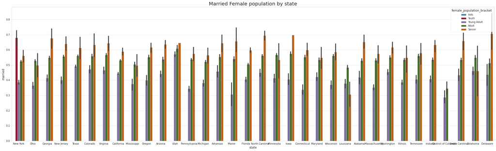

```python
sns.set_style("whitegrid")
plt.figure(figsize = (35, 10))

ax = sns.barplot(x = 'state', y = 'married', hue = 'female_population_bracket', data = age_df, palette=color_pal,
           order = ['New York', 'Ohio', 'Georgia', 'New Jersey', 'Texas', 'Colorado', 'Virginia', 'California', 'Mississippi', 'Oregon', 'Arizona', 'Utah', 'Pennsylvania', 'Michigan', 'Arkansas', 'Maine', 'Florida', 'North Carolina',
                     'Minnesota', 'Iowa', 'Connecticut', 'Maryland', 'Wisconsin', 'Louisiana', 'Alabama', 'Massachusetts', 'Washington', 'Illinois', 'Tennessee', 'Indiana', 'District of Columbia', 'South Carolina', 'Oklahoma', 'Delaware'])

ax.set_title('Married Female population by state', fontsize = 20)

plt.show()
```

# Except for "Newyork", NO other state has Married Female KIDS or Youth

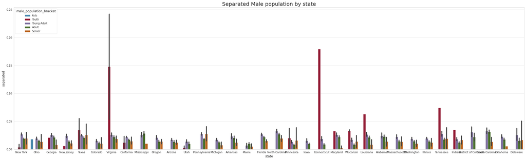

```python
sns.set_style("whitegrid")
plt.figure(figsize = (35, 10))

ax = sns.barplot(x = 'state', y = 'separated', hue = 'male_population_bracket', data = age_df, palette=color_pal,
           order = ['New York', 'Ohio', 'Georgia', 'New Jersey', 'Texas', 'Colorado', 'Virginia', 'California', 'Mississippi', 'Oregon', 'Arizona', 'Utah', 'Pennsylvania', 'Michigan', 'Arkansas', 'Maine', 'Florida', 'North Carolina',
                     'Minnesota', 'Iowa', 'Connecticut', 'Maryland', 'Wisconsin', 'Louisiana', 'Alabama', 'Massachusetts', 'Washington', 'Illinois', 'Tennessee', 'Indiana', 'District of Columbia', 'South Carolina', 'Oklahoma', 'Delaware'])

ax.set_title('Separated Male population by state', fontsize = 20)

plt.show()
```

# "Connecticut, followed by Virginia", has Highest Separated Male Youth population

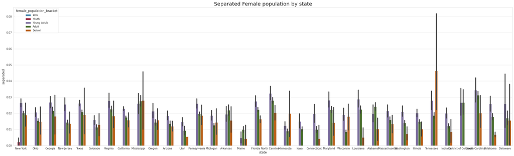

```python
sns.set_style("whitegrid")
plt.figure(figsize = (35, 10))

ax = sns.barplot(x = 'state', y = 'separated', hue = 'female_population_bracket', data = age_df, palette=color_pal,
           order = ['New York', 'Ohio', 'Georgia', 'New Jersey', 'Texas', 'Colorado', 'Virginia', 'California', 'Mississippi', 'Oregon', 'Arizona', 'Utah', 'Pennsylvania', 'Michigan', 'Arkansas', 'Maine', 'Florida', 'North Carolina',
                     'Minnesota', 'Iowa', 'Connecticut', 'Maryland', 'Wisconsin', 'Louisiana', 'Alabama', 'Massachusetts', 'Washington', 'Illinois', 'Tennessee', 'Indiana', 'District of Columbia', 'South Carolina', 'Oklahoma', 'Delaware'])

ax.set_title('Separated Female population by state', fontsize = 20)

plt.show()
```

# Except for "Newyork", No other state has Separated Female Youth population "Tennessee" has the Highest Separated Female SENIOR population

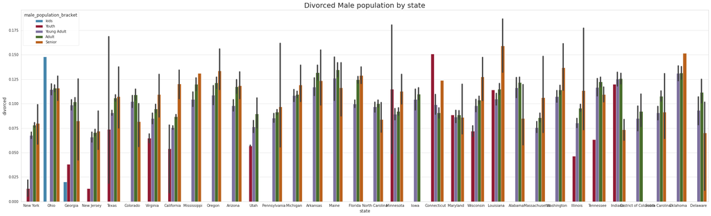

```python
sns.set_style("whitegrid")
plt.figure(figsize = (35, 10))

ax = sns.barplot(x = 'state', y = 'divorced', hue = 'male_population_bracket', data = age_df, palette=color_pal,
           order = ['New York', 'Ohio', 'Georgia', 'New Jersey', 'Texas', 'Colorado', 'Virginia', 'California', 'Mississippi', 'Oregon', 'Arizona', 'Utah', 'Pennsylvania', 'Michigan', 'Arkansas', 'Maine', 'Florida', 'North Carolina',
                     'Minnesota', 'Iowa', 'Connecticut', 'Maryland', 'Wisconsin', 'Louisiana', 'Alabama', 'Massachusetts', 'Washington', 'Illinois', 'Tennessee', 'Indiana', 'District of Columbia', 'South Carolina', 'Oklahoma', 'Delaware'])

ax.set_title('Divorced Male population by state', fontsize = 20)

plt.show()
```

# "Ohio", has Largest number of Divorced Male KIDS. "Connecticut", has Largest number of Divorced Male YOUTH. "Maine, Indiana & Oklahoma", has Largest number of Divorced Male YOUNG ADULTS "Arkansas, Maine, Indiana & Oklahoma", has Largest number of Divorced Male ADULTS "Louisiana & OKlahoma", has Largest number of Divorced Male SENIORS. Looks like "OKlahoma", is the Divorce Capital for MALE population.

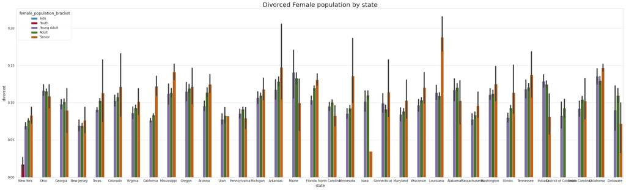

```python
sns.set_style("whitegrid")

plt.figure(figsize = (35, 10))

ax = sns.barplot(x = 'state', y = 'divorced', hue = 'female_population_bracket', data = age_df, palette=color_pal,
           order = ['New York', 'Ohio', 'Georgia', 'New Jersey', 'Texas', 'Colorado', 'Virginia', 'California', 'Mississippi', 'Oregon', 'Arizona', 'Utah', 'Pennsylvania', 'Michigan', 'Arkansas', 'Maine', 'Florida', 'North Carolina',
                     'Minnesota', 'Iowa', 'Connecticut', 'Maryland', 'Wisconsin', 'Louisiana', 'Alabama', 'Massachusetts', 'Washington', 'Illinois', 'Tennessee', 'Indiana', 'District of Columbia', 'South Carolina', 'Oklahoma', 'Delaware'])

ax.set_title('Divorced Female population by state', fontsize = 20)

plt.show()
```

# "Newyork", is the only state that has Divorced Female YOUTH. "Maine", has Largest number of Divorced Female YOUNG ADULTS "Maine", has Largest number of Divorced Female ADULTS "Louisiana", has Largest number of Divorced Female SENIORS.

# 3. Please detail your observations for rent as a percentage of income at an overall level, and for different states.

```python
train_df.head()
```

|  | UID | SUMLEVEL | COUNTYID | STATEID | state | state_ab | city | place | type | zip_code | area_code | lat | lng | ALand | AWater | pop | male_pop | female_pop | rent_mean | rent_median | rent_stdev | rent_sample_weight | rent_samples | rent_gt_10 | rent_gt_15 | rent_gt_20 | rent_gt_25 | rent_gt_30 | rent_gt_35 | … |
| --- | --- | --- | --- | --- | --- | --- | --- | --- | --- | --- | --- | --- | --- | --- | --- | --- | --- | --- | --- | --- | --- | --- | --- | --- | --- | --- | --- | --- | --- | --- |
| 0 | 267822 | 140 | 53 | 36 | New York | NY | Hamilton | Hamilton | City | 13346 | 315 | 42.840812 | -75.501524 | 202183361.0 | 1699120 | 5230 | 2612 | 2618 | 769.38638 | 784.0 | 232.63967 | 272.34441 | 362.0 | 0.86761 | 0.79155 | 0.59155 | 0.45634 | 0.42817 | 0.18592 | … |
| 1 | 246444 | 140 | 141 | 18 | Indiana | IN | South Bend | Roseland | City | 46616 | 574 | 41.701441 | -86.266614 | 1560828.0 | 100363 | 2633 | 1349 | 1284 | 804.87924 | 848.0 | 253.46747 | 312.58622 | 513.0 | 0.97410 | 0.93227 | 0.69920 | 0.69920 | 0.55179 | 0.41235 | … |
| 2 | 245683 | 140 | 63 | 18 | Indiana | IN | Danville | Danville | City | 46122 | 317 | 39.792202 | -86.515246 | 69561595.0 | 284193 | 6881 | 3643 | 3238 | 742.77365 | 703.0 | 323.39011 | 291.85520 | 378.0 | 0.95238 | 0.88624 | 0.79630 | 0.66667 | 0.39153 | 0.39153 | … |
| 3 | 279653 | 140 | 127 | 72 | Puerto Rico | PR | San Juan | Guaynabo | Urban | 927 | 787 | 18.396103 | -66.104169 | 1105793.0 | 0 | 2700 | 1141 | 1559 | 803.42018 | 782.0 | 297.39258 | 259.30316 | 368.0 | 0.94693 | 0.87151 | 0.69832 | 0.61732 | 0.51397 | 0.46927 | … |
| 4 | 247218 | 140 | 161 | 20 | Kansas | KS | Manhattan | Manhattan City | City | 66502 | 785 | 39.195573 | -96.569366 | 2554403.0 | 0 | 5637 | 2586 | 3051 | 938.56493 | 881.0 | 392.44096 | 1005.42886 | 1704.0 | 0.99286 | 0.98247 | 0.91688 | 0.84740 | 0.78247 | 0.60974 | … |

```python
rent_df = train_df[['state', 'city', 'rent_median', 'hi_median', 'family_median']]
```

```python
Overall_rent_percentage = (rent_df['rent_median'].sum() / rent_df['hi_median'].sum()) * 100
round(Overall_rent_percentage, 2)
```

```
1.74
```

# Overall Rent as a percentage of Overall House Hold Income is around 1.74%.

```python
rent_df['ov_rent_pcnt'] = round((rent_df['rent_median'] / rent_df['hi_median']) * 100, 2)
```

```python
rent_df.head()
```

|  | state | city | rent_median | hi_median | family_median | ov_rent_pcnt |
| --- | --- | --- | --- | --- | --- | --- |
| 0 | New York | Hamilton | 784.0 | 48120.0 | 53245.0 | 1.63 |
| 1 | Indiana | South Bend | 848.0 | 35186.0 | 43023.0 | 2.41 |
| 2 | Indiana | Danville | 703.0 | 74964.0 | 85395.0 | 0.94 |
| 3 | Puerto Rico | San Juan | 782.0 | 37845.0 | 44399.0 | 2.07 |
| 4 | Kansas | Manhattan | 881.0 | 22497.0 | 50272.0 | 3.92 |

```python
print(list(rent_df.nlargest(500, 'ov_rent_pcnt').state.unique()))
print(len(list(rent_df.nlargest(500, 'ov_rent_pcnt').state.unique())))
```

```
['Georgia', 'Texas', 'California', 'New York', 'Florida', 'Washington', 'Oregon', 'Pennsylvania', 'Maryland', 'Virginia', 'Mississippi', 'Alabama', 'Michigan', 'Louisiana', 'Iowa', 'Puerto Rico', 'New Jersey', 'Illinois', 'Arizona', 'North Carolina', 'South Carolina', 'Tennessee', 'Ohio', 'Wisconsin…
40
```

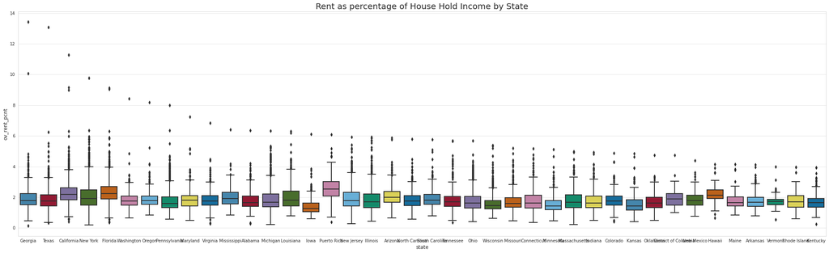

```python
sns.set_style("whitegrid")
plt.figure(figsize = (35, 10))
ax = sns.boxplot(x = 'state', y = 'ov_rent_pcnt', data=rent_df.nlargest(26585, 'ov_rent_pcnt'), palette=color_pal,
            order = ['Georgia', 'Texas', 'California', 'New York', 'Florida', 'Washington', 'Oregon', 'Pennsylvania', 'Maryland', 'Virginia', 'Mississippi', 'Alabama', 'Michigan', 'Louisiana',
                     'Iowa', 'Puerto Rico', 'New Jersey', 'Illinois', 'Arizona', 'North Carolina', 'South Carolina', 'Tennessee', 'Ohio', 'Wisconsin', 'Missouri', 'Connecticut', 'Minnesota',
                     'Massachusetts', 'Indiana', 'Colorado', 'Kansas', 'Oklahoma', 'District of Columbia', 'New Mexico', 'Hawaii', 'Maine', 'Arkansas', 'Vermont', 'Rhode Island', 'Kentucky']
           ).set_title('Rent as percentage of House Hold Income by State', fontsize = 20)
#ax.set(ylim=(0, 100))
plt.show()
```